# Chapter 5

[Bruce Hartman](https://drbrucehartman.net/brucewebsite/)

Last updated: 12 January, 2025

# Introduction

Solve Chapter 5 Problems from the HEADS text.

# Packages

Regular R packages:

```r
library(tidyverse)
library(ggfortify)
library(GGally)
library(broom)
library(skimr)
library(gt)
library(patchwork)
library(yardstick)
library(car)
```

For this text:

```r
library(HEADS)
```

[output not shown]

# Data

```r
data(Table_5_1, package="HEADS")
Table_5_1
```

| Age | SBP |
| --- | --- |
| 22 | 131 |
| 23 | 128 |
| 24 | 116 |
| 27 | 106 |
| 28 | 114 |
| 29 | 123 |
| 30 | 117 |
| 32 | 122 |
| 33 | 99 |
| 35 | 121 |

[output cut: 23 more lines]

# Chapter 5

## Linear Regression (5.1)

Figure 5.1.

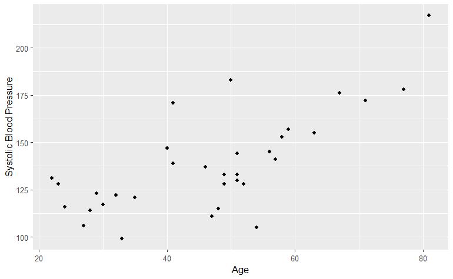

```r
ggplot(Table_5_1, aes(Age, SBP)) +
  geom_point() +
  labs(y = "Systolic Blood Pressure")
```

Make predictions and add predictions to plot Figure 5.2

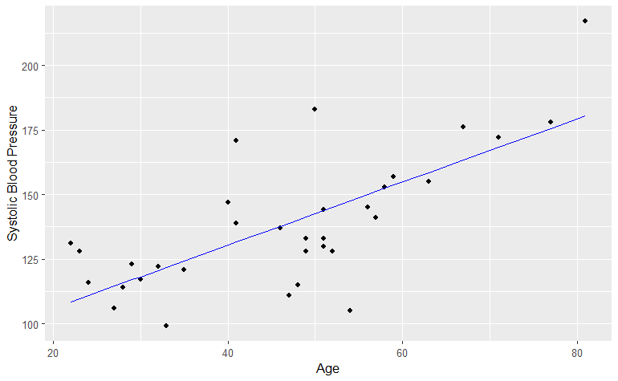

```r
fit=lm(SBP~Age, data=Table_5_1)
pred = predict(fit)
ggplot(Table_5_1, aes(Age, SBP)) +
  geom_point() +
  labs(y = "Systolic Blood Pressure") +
  geom_line(aes(y=pred), color="blue")
```

Alternative plot:

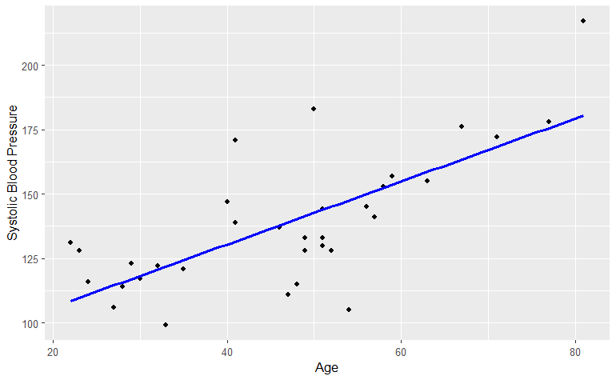

```r
ggplot(Table_5_1, aes(Age, SBP)) +
  geom_point() +
  labs(y = "Systolic Blood Pressure") +
  geom_smooth(method="lm", formula='y~x', se=F, color="blue")
```

```r
fit %>% coef
```

```
(Intercept)         Age
  81.516752    1.222404
```

```r
fit %>% tidy
```

| term | estimate | std.error | statistic | p.value |
| --- | --- | --- | --- | --- |
| (Intercept) | 81.516752 | 10.4652693 | 7.789265 | 8.655142e-09 |
| Age | 1.222404 | 0.2129289 | 5.740903 | 2.569329e-06 |

### Validation of Coefficients (5.1.2)

Confidence intervals:

```r
fit %>% tidy(conf.int=T)
```

| term | estimate | std.error | statistic | p.value | conf.low | conf.high |
| --- | --- | --- | --- | --- | --- | --- |
| (Intercept) | 81.516752 | 10.4652693 | 7.789265 | 8.655142e-09 | 60.1726946 | 102.860810 |
| Age | 1.222404 | 0.2129289 | 5.740903 | 2.569329e-06 | 0.7881328 | 1.656676 |

Hypothesis tests:

- $H0: \beta1 = 0$ vs.
- $H1: \beta1 ̸= 0.$

```r
fit %>% tidy %>% dplyr::select(term, estimate, statistic, p.value)
```

| term | estimate | statistic | p.value |
| --- | --- | --- | --- |
| (Intercept) | 81.516752 | 7.789265 | 8.655142e-09 |
| Age | 1.222404 | 5.740903 | 2.569329e-06 |

R-squared:

```r
fit %>% glance
```

| r.squared | adj.r.squared | sigma | statistic | p.value | df | logLik | AIC | BIC | deviance | df.residual | nobs |
| --- | --- | --- | --- | --- | --- | --- | --- | --- | --- | --- | --- |
| 0.5153066 | 0.4996714 | 18.63894 | 32.95796 | 2.569329e-06 | 1 | -142.3267 | 290.6535 | 295.143 | 10769.71 | 31 | 33 |

```r
fit %>% anova %>% tidy()
```

| term | df | sumsq | meansq | statistic | p.value |
| --- | --- | --- | --- | --- | --- |
| Age | 1 | 11449.93 | 11449.93 | 32.95796 | 2.569329e-06 |
| Residuals | 31 | 10769.71 | 347.41 | NA | NA |

## Multiple Linear Regression (5.2)

### Example 5.2.1

The dataset is in Table 5.3 and is based on Robertson and Armitage, 1959.

```r
data(Table_5_3)
Table_5_3
```

| LogDose | DBP | RT | PredictedRT |
| --- | --- | --- | --- |
| 5.20 | 66 | 7 | 28.75 |
| 4.17 | 52 | 10 | 28.16 |
| 4.10 | 72 | 18 | 12.61 |
| 3.55 | 67 | 4 | 10.46 |
| 4.74 | 69 | 10 | 21.64 |
| 4.01 | 71 | 13 | 12.39 |
| 5.89 | 88 | 21 | 19.81 |
| 5.27 | 68 | 12 | 28.02 |
| 4.14 | 59 | 9 | 22.66 |
| 5.34 | 73 | 65 | 25.06 |

[output cut: 43 more lines]

Figure 5.3.

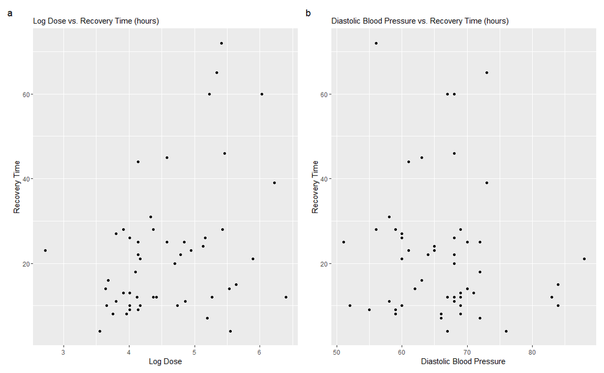

```r
p1 = ggplot(Table_5_3, aes(x=LogDose)) +
  geom_point(aes(y=RT)) +
  labs(y="Recovery Time",
       x="Log Dose",
       subtitle="Log Dose vs. Recovery Time (hours)")
p2 = ggplot(Table_5_3, aes(x=DBP)) +
  geom_point(aes(y=RT)) +
  labs(y="Recovery Time",
       x="Diastolic Blood Pressure",
       subtitle="Diastolic Blood Pressure vs. Recovery Time (hours)")

p1 + p2 + plot_annotation(tag_levels='a')
```

Simple Way:

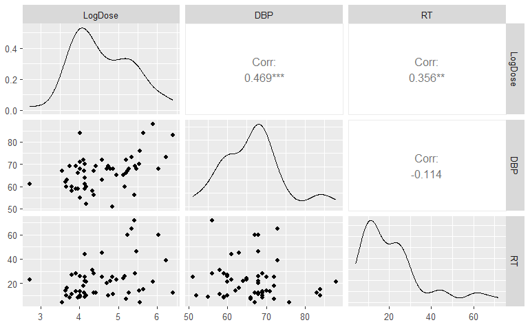

```r
Table_5_3 %>% dplyr::select(LogDose,DBP,RT) %>% GGally::ggpairs(progress=F)
```

Regression and overall results:

```r
fit53 = lm(RT~LogDose+DBP, data=Table_5_3)
fit53 %>% glance
```

| r.squared | adj.r.squared | sigma | statistic | p.value | df | logLik | AIC | BIC | deviance | df.residual | nobs |
| --- | --- | --- | --- | --- | --- | --- | --- | --- | --- | --- | --- |
| 0.2275364 | 0.1966378 | 14.24412 | 7.363984 | 0.001573805 | 2 | -214.4459 | 436.8917 | 444.7729 | 10144.75 | 50 | 53 |

Coefficients:

```r
fit53 %>% tidy(conf.int=T)
```

| term | estimate | std.error | statistic | p.value | conf.low | conf.high |
| --- | --- | --- | --- | --- | --- | --- |
| (Intercept) | 22.2712356 | 17.5548999 | 1.268662 | 0.2104363762 | -12.988819 | 57.5312897 |
| LogDose | 10.6399266 | 2.8555863 | 3.726004 | 0.0004955862 | 4.904313 | 16.3755405 |
| DBP | -0.7400894 | 0.2893218 | -2.558014 | 0.0136044947 | -1.321209 | -0.1589694 |

We should always check residuals:

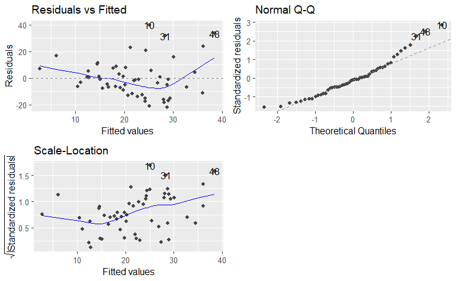

```r
fit53 %>% autoplot(1:3)
```

We won’t comment on residuals here.

### Example 5.2.2

The F-test comes from the glance output.

### Example 5.2.3 and 5.2.4

The coefficient tests and confidence intervals come from the tidy output.

## Variable Transformation (5.3)

### Example 5.3.1 and 5.3.2

Categorical variables can be dichotomous with just two values, and usually encoded 0-1 or with text. Some can have three or more levels, often encoded as text.

Data from Table 5.4:

```r
data(Table_5_4)
Table_5_4
```

| Ethnicity | WaitingTime |
| --- | --- |
| Non-Latino | 1012 |
| Non-Latino | 1307 |
| Non-Latino | 2474 |
| Non-Latino | 390 |
| Non-Latino | 77 |
| Latino | 1048 |
| Latino | 3255 |
| Latino | 1190 |
| Latino | 1458 |
| Latino | 1090 |

[output cut: 20 more lines]

Code the ethnicity using factor.

```r
Table_5_4$Ethnicity = as.factor(Table_5_4$Ethnicity)
```

Regression model:

```r
fit54 = lm(WaitingTime ~ Ethnicity, data=Table_5_4)
fit54 %>% tidy
```

| term | estimate | std.error | statistic | p.value |
| --- | --- | --- | --- | --- |
| (Intercept) | 1141.4 | 205.2674 | 5.560552 | 6.008446e-06 |
| EthnicityNon-Latino | -303.6 | 290.2919 | -1.045844 | 3.045782e-01 |

Non-Latino patients get kidneys on average 303.6 days earlier.

```r
Table_5_4a = Table_5_4 %>%
  mutate(Ethnicity1 = ifelse(Ethnicity == "Latino", 1, -1))
fit54a = lm(WaitingTime ~ Ethnicity1, data=Table_5_4a)
fit54a %>% tidy
```

| term | estimate | std.error | statistic | p.value |
| --- | --- | --- | --- | --- |
| (Intercept) | 989.6 | 145.146 | 6.817964 | 2.088310e-07 |
| Ethnicity1 | 151.8 | 145.146 | 1.045844 | 3.045782e-01 |

Matches the book.

Another approach:

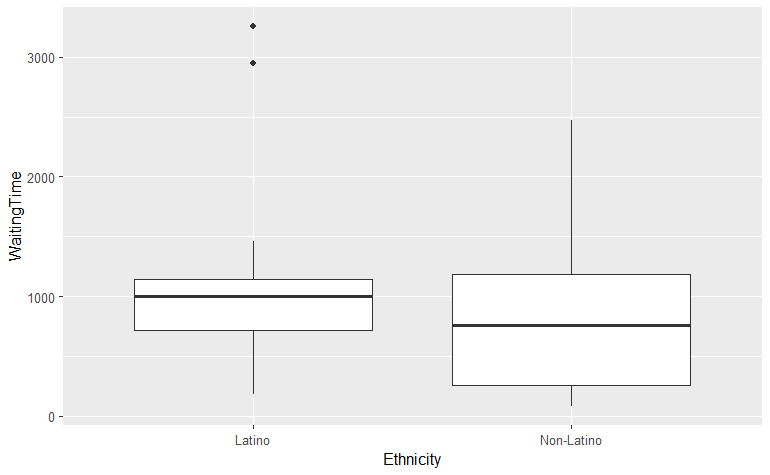

```r
ggplot(Table_5_4) +
  geom_boxplot(aes(x=Ethnicity, y=WaitingTime))
```

# References

Mehrotra, Sanjay, Kevin Bui, and Hari Balasubramanian (2024). Healthcare Engineering, Analytics, and Decision Sciences: An Introduction. December 11, 2024. (https://sites.google.com/view/healthcareengineering/)

JD Robertson and P Armitage (1959) Comparison of two hypotensive agents. Anaesthesia, 14(1):53–64.